# Democratic Effort Study 1: Data Cleaning

# Democratic Effort Task Data Cleaning

**Code was adapted from:**

Cutler, J., Contreras-Huerta, L. S., Todorova, B., Nitschke, J. P., Michalaki, K., Koppel, L., Gkinopoulos, T., Vogel, T. A., Lamm, C., Västfjäll, D., Tsakiris, M., Apps, M. A. J., & Lockwood, P. (2024). Psychological interventions increase motivation to exert effort to mitigate climate change. PsyArXiv. https://doi.org/10.31234/osf.io/c8yxs

## Load and clean data

```r
raw <- read.csv(here(data_raw_dir , "demeffort_raw.csv"))
```

```r
clean <- raw |>
  slice(-(1:2)) |>  # remove first two rows of meta data
  filter(Calib1 != "" & !is.na(Calib1))

# Check for duplicate Prolific IDs
duplicates <- clean |>
  count(Q1) |>
  filter(n > 1)

cat("Duplicate Prolific IDs found:", nrow(duplicates))
```

```
Duplicate Prolific IDs found: 2
```

```r
# Remove duplicate submissions (keep earliest submission only)
clean <- clean |>
  arrange(Q1, StartDate) |>
  group_by(Q1) |>
  slice(1) |>  # Keep first (earliest) submission
  ungroup()

n_participants <- clean %>%
  n_distinct("ResponseId")

print(paste("N completed =", n_participants))
```

```
[1] "N completed = 298"
```

Trial numbering is 4:36 as we removed the lowest effort level (50%) and added a third condition –> change to 1:27

```r
old_choice_names <- c(
  "X4_choice_screen","X5_choice_screen","X6_choice_screen","X7_choice_screen",
  "X8_choice_screen","X9_choice_screen","X10_choice_screen","X11_choice_screen",
  "X12_choice_screen","X16_choice_screen","X17_choice_screen","X18_choice_screen",
  "X19_choice_screen","X20_choice_screen","X21_choice_screen","X22_choice_screen",
  "X23_choice_screen","X24_choice_screen","X28_choice_screen","X29_choice_screen",
  "X30_choice_screen","X31_choice_screen","X32_choice_screen","X33_choice_screen",
  "X34_choice_screen","X35_choice_screen","X36_choice_screen"
)

clean <- clean |>
  rename_with(~ paste0("X", 1:27, "_choice_screen"), all_of(old_choice_names))
```

```r
old_work_names <- c(
  "X4_work_feedback_timing_Page.Submit","X5_work_feedback_timing_Page.Submit",
  "X6_work_feedback_timing_Page.Submit","X7_work_feedback_timing_Page.Submit",
  "X8_work_feedback_timing_Page.Submit","X9_work_feedback_timing_Page.Submit",
  "X10_work_feedback_timing_Page.Submit","X11_work_feedback_timing_Page.Submit",
  "X12_work_feedback_timing_Page.Submit","X16_work_feedback_timing_Page.Submit",
  "X17_work_feedback_timing_Page.Submit","X18_work_feedback_timing_Page.Submit",
  "X19_work_feedback_timing_Page.Submit","X20_work_feedback_timing_Page.Submit",
  "X21_work_feedback_timing_Page.Submit","X22_work_feedback_timing_Page.Submit",
  "X23_work_feedback_timing_Page.Submit","X24_work_feedback_timing_Page.Submit",
  "X28_work_feedback_timing_Page.Submit","X29_work_feedback_timing_Page.Submit",
  "X30_work_feedback_timing_Page.Submit","X31_work_feedback_timing_Page.Submit",
  "X32_work_feedback_timing_Page.Submit","X33_work_feedback_timing_Page.Submit",
  "X34_work_feedback_timing_Page.Submit","X35_work_feedback_timing_Page.Submit",
  "X36_work_feedback_timing_Page.Submit"
)

clean <- clean |>
  rename_with(~ paste0("X", 1:27, "_work_feedback_timing_Page.Submit"),
              all_of(old_work_names))
```

## Create structured dataframe for boxes task from Qualtrics output

The output from Qualtrics is a bit messy and in a wide format. Here we create a long format dataframe that matches the order of the trials from the Loop & Merge spreadsheet in the Qualtrics task. We recreate the trial order from the spreadsheet and add each participants data to it. The trial orders are randomized between participants, but Qualtrics outputs trials in the same order that they appear in the Loop & Merge spreadsheet of the task.

### Code the choice data

Grab choice for each trial: - There are 27 trials, corresponding to the row number from the Loop & Merge spreadsheet. So there are 27 “#_choice_screen” that appear, where “#” is the corresponding row number from the Loop & Merge spreadsheet

The code Loops through columns and gets the choice made (3 credits for Rest vs X credits for Y boxes) and recodes them to 0 and 1 NOTE: read.csv adds an “X” to front of variables that start with a number (e.g., 1_choice_screen becomes X1_choice_screen) Using another package like readr to load in the csv may not do this, and so the code in paste0() below will need to be changed

In Qualtrics, choices were coded as: 1 = “${lm://Field/2} credits for ${lm://Field/3} boxes” (Work) 2 = “3 credits for Rest” (Rest)

We recode these so that: NA = No decision 0 = Rest 1 = Work

```r
choice_data <- sapply(1:27, function(i) {
  recode(clean[[paste0("X", i, "_choice_screen")]],
                "1" = 1,   # Work
                "2" = 0,   # Rest
                .default = NA_real_ # No decision
  )
})
```

### Code the work success

Grab work success (clicked all boxes) for each trial: If participants chose Work (decision = 1), then the “_work_feedback_timing_Page.Submit” only appears if they successfully clicked all the boxes on the screen. If participants chose Rest (decision = 0), success should be NA (not applicable).

```r
work_success_data <- sapply(1:27, function(i) {
  tmp <- as.numeric(clean[[paste0("X", i, "_work_feedback_timing_Page.Submit")]])
  ifelse(choice_data[, i] == 1,   # only check success if Work was chosen
         ifelse(is.na(tmp), 0, 1),  # Work chosen → 1 = success, 0 = fail
         NA_real_)                  # Rest chosen → NA (not applicable)
})
```

### Create task dataframe

Create a new dataframe, with a structure that can be used to fit models: There are 27 trials in total, so variables need to be repeated to fill all the rows for each participant.

Note: the order of the dataframe does not match the order that participants saw the trials. Qualtrics does not output the trial-order seen, and instead outputs the responses for each trial in the order that they appear in the Loop & Merge spreadsheet.

```r
# Create the trial structure template (27 trials)
trial_structure <- expand_grid(
  agent = c("VOTEALL", "VOTERURAL", "VOTEURBAN"),
  eff = c("easy65", "hard80", "hard95"),
  rew = c(4, 12, 20)) |>
  mutate(
    eff = factor(eff, levels = c("easy65", "hard80", "hard95")),
    rew = factor(rew, levels = c(4, 12, 20)))

# Create the main dataframe
task_data <- tibble(
  id = rep(clean$ResponseId, each = 27)
) |>
  # Add trial structure for each participant
  bind_cols(
    bind_rows(replicate(n_participants, trial_structure, simplify = FALSE))
  ) |>
  # Add choice and success data
  mutate(
    decision = c(t(choice_data)),
    success = c(t(work_success_data))
  ) |>
  # Add participant-level variables (repeated for each trial)
  left_join(
    clean |>
      select(ResponseId, max_boxes, easy65, hard80, hard95) |>
      rename(
        id = ResponseId,
        easy65_nboxes = easy65,
        hard80_nboxes = hard80,
        hard95_nboxes = hard95
      ),
    by = "id"
  )
```

### New ID variable

```r
# Create mapping from original IDs to participant IDs
id_mapping <- task_data |>
  distinct(id) |>
  arrange(id) |>  # Ensures consistent ordering
  mutate(
    PID = paste0("P", str_pad(row_number(), width = 2, pad = "0"))
  )

# Add the new participant ID to your data
task_data <- task_data |>
  left_join(id_mapping, by = "id")

# reorder task data
task_data <- task_data |>
  select(id, PID, agent:hard95_nboxes)
```

## Create survey dataframe

```r
survey_data <- clean |>
  select(PROLIFIC_PID = Q1,
         id = ResponseId,
         date = RecordedDate,
         timer_total = `Duration..in.seconds.`,
         manip_check_01, manip_check_02,
         donation_decision,
         party,
         party_open = party_4_TEXT,
         party_strength,
         party_closer,
         party_identity_strength = partisan_identity,
         valence_democrats = valence_democrats_6,
         valence_republicans = valence_republicans_24,
         arousal_democrats = arousal_democrats_24,
         arousal_republicans = arousal_republicans_24,
         bipartisanship_01 = bipartisanship_01_24,
         bipartisanship_02 = bipartisanship_02_24,
         friends_democrats = friends_democrats_24,
         friends_republicans = friends_republicans_24,
         ideology = ideology_24,
         dem_01:dem_03,
         dem_04:dem_07,
         vote_election:political_follow,
         health_general = general_health,
         health_politics_01:health_politics_05,
         health_politics_06:health_politics_10,
         PSS4_01:PSS4_10,
         stress_politics,
         depression_01:depression_08,
         age = age_1,
         gender,
         gender_open = gender_3_TEXT,
         rururb01, rururb02,
         rururb02_open = rururb02_5_TEXT,
         rururb03,
         education,
         ethnicity,
         ethicity_open = ethnicity_7_TEXT,
         income,
         max_boxes:hard95,
         commitment,
         attention_01, attention_02) |>
  rename_with(~str_replace(., "PSS4_", "PSS_"), starts_with("PSS4_"))

survey_data <- survey_data |>
  left_join(task_data |> select(id, PID) |> distinct(), by = "id")
```

#### Set datatypes

```r
survey_data <- survey_data |>
  separate(ethnicity, into = c("ethnicity01", "ethnicity02"), sep = ",", fill = "right") |>
  mutate(
    # Factor variables
    donation_decision = factor(donation_decision,
                              levels = c("1", "2"),
                              labels = c("Donate", "Keep")),

    manip_check_01 = factor(manip_check_01,
                           levels = c("1", "2", "3", "4"),
                           labels = c("Republican", "Democrat", "Independent", "Other")),

    manip_check_02 = factor(manip_check_02,
                           levels = c("1", "2", "3", "4", "5"),
                           labels = c("Democrats", "Republicans",
                                     "Both Democrats and Republicans",
                                     "Neither Democrats nor Republicans", "Other")),

    party = factor(party,
                  levels = c("1", "2", "3", "4"),
                  labels = c("Democrat", "Republican", "Independent", "Other")),

    party_strength = factor(party_strength,
                           levels = c("1", "2"),
                           labels = c("Strong", "Not very strong")),

    party_closer = factor(party_closer,
                         levels = c("1", "2"),
                         labels = c("Democrat", "Republican")),

    vote_election = factor(vote_election,
                          levels = c("1", "2"),
                          labels = c("No", "Yes")),

    gender = factor(gender,
                   levels = c("1", "2", "3", "4"),
                   labels = c("Man", "Woman", "Other", "Prefer not to say")),

    rururb01 = factor(rururb01,
                     levels = c("1", "2", "3", "4"),
                     labels = c("Rural area", "Small town", "Suburb", "City")),

    rururb02 = factor(rururb02,
                     levels = c("1", "2", "3", "4", "5"),
                     labels = c("City", "Suburb", "Small-town", "Rural", "Other")),

    education = factor(education,
                      levels = c("1", "2", "3", "4", "5", "6"),
                      labels = c("Less than high school", "High school",
                                "College, but not degree", "2-year college degree",
                                "4-year college degree", "Postgraduate degree")),

    ethnicity01 = factor(ethnicity01,
                        levels = c("1", "2", "3", "4", "5", "6", "7"),
                        labels = c("White", "Black or African-American",
                                  "Hispanic, Latino, or Spanish origin",
                                  "American Indian or Alaska Native", "Asian",
                                  "Native Hawaiian or other Pacific Islander", "Other")),

    ethnicity02 = factor(ethnicity02,
                        levels = c("1", "2", "3", "4", "5", "6", "7"),
                        labels = c("White", "Black or African-American",
                                  "Hispanic, Latino, or Spanish origin",
                                  "American Indian or Alaska Native", "Asian",
                                  "Native Hawaiian or other Pacific Islander", "Other")),

    income = factor(income,
                   levels = c("1", "2", "3", "4", "5", "6", "7", "8", "9", "10", "11", "12"),
                   labels = c("Less than $10,000", "$10,000 to $19,999", "$20,000 to $29,999",
                             "$30,000 to $39,999", "$40,000 to $49,999", "$50,000 to $59,999",
                             "$60,000 to $69,999", "$70,000 to $79,999", "$80,000 to $89,999",
                             "$90,000 to $99,999", "$100,000 to $149,999", "$150,000 or more")),

    commitment = factor(commitment,
                        levels = c("1", "2", "3"),
                        labels = c("I can’t promise either way",
                                   "Yes, I will",
                                   "No, I will not")),

    attention_01 = factor(if_else(attention_01 == "5", "passed", "failed"),
                         levels = c("passed", "failed")),

    attention_02 = factor(if_else(attention_02 == "1", "passed", "failed"),
                         levels = c("passed", "failed"))
  ) |>
  mutate(
    across(c(valence_democrats, valence_republicans,
             arousal_democrats, arousal_republicans,
             bipartisanship_01, bipartisanship_02,
             friends_democrats, friends_republicans,
             ideology,
             party_identity_strength, vote_importance,
             political_interest, political_discussion, political_follow,
             health_general, stress_politics, rururb03,
             max_boxes, easy50, easy65, hard80, hard95,
             age,
             starts_with("dem_"),
             starts_with("health_politics_"),
             starts_with("PSS_"),
             starts_with("depression_")),
           as.numeric)
  )
```

#### Calculate integrated/scale scores

##### Add summaries from the political effort task to the survey data

1. work_total: Overall work count (0-27)
2. work_voteall: Work decisions when agent=“VOTEALL”
3. work_voteurban: Work decisions when agent=“VOTEURBAN”
4. work_voterural: Work decisions when agent=“VOTERURAL”

```r
work_summaries <- task_data |>
  group_by(id) |>
  summarise(
    # Work decisions across all conditions
    work_total = sum(decision == 1, na.rm = TRUE),

    # Work decisions by agent condition
    work_voteall = sum(decision == 1 & agent == "VOTEALL", na.rm = TRUE),
    work_voteurban = sum(decision == 1 & agent == "VOTEURBAN", na.rm = TRUE),
    work_voterural = sum(decision == 1 & agent == "VOTERURAL", na.rm = TRUE),

    .groups = "drop"
  )

survey_data <- survey_data |>
  left_join(work_summaries, by = "id")
```

##### Partisanship & Partisan strength

We have three items asking for partisanship. 1. The first item has four options: Democrat / Republican / Independent / Other 2. If participants select Independent / Other -> they see another question with the options Closer to Democrat / Republican 3. If participants select Democrat / Republican -> they see another question with the options Not very strong / strong Democrat / Republican

And then we also want to calculate: 1. Overall decision to work for ingroup / outgroup and ingroup - outgroup

```r
survey_data <- survey_data |>
  mutate(
    # Party preference: Democrat/Republican based on main choice or closer leaning
    party_preference = case_when(
      party %in% c("Democrat", "Republican") ~ as.character(party),
      party %in% c("Independent", "Other") & party_closer == "Democrat" ~ "Democrat",
      party %in% c("Independent", "Other") & party_closer == "Republican" ~ "Republican",
      .default = NA_character_
    ),

    # Party intensity: 0=Independent/Other, 1=Not very strong, 2=Strong
    party_intensity = case_when(
      party %in% c("Independent", "Other") ~ 0,
      party %in% c("Democrat", "Republican") & party_strength == "Not very strong" ~ 1,
      party %in% c("Democrat", "Republican") & party_strength == "Strong" ~ 2,
      .default = NA_real_
    )
  ) |>
  # Convert party_preference to factor with explicit levels
  mutate(
    party_preference = factor(party_preference, levels = c("Democrat", "Republican"))
  ) |>
  mutate(
    # Create work_ingroup variable
    work_ingroup = case_when(
      party_preference == "Democrat" ~ work_voteurban,
      party_preference == "Republican" ~ work_voterural,
      TRUE ~ NA_real_  # For any other values or NAs
    ),

    # Create work_outgroup variable
    work_outgroup = case_when(
      party_preference == "Democrat" ~ work_voterural,
      party_preference == "Republican" ~ work_voteurban,
      TRUE ~ NA_real_  # For any other values or NAs
    ),

    # Calculate the difference
    work_difference = work_ingroup - work_outgroup
  )
```

##### Affective Polarisation

Calculation of affective polarisation including weighted score by arousal following Kasper et al. (in prep)

```r
pol_long <- survey_data |>
  select(id,
         val_democrats = valence_democrats,
         val_republicans = valence_republicans,
         ars_democrats = arousal_democrats,
         ars_republicans = arousal_republicans) |>
  pivot_longer(
    cols = -c(id),
    names_to = c("measure", "party"),
    names_pattern = "([a-z]+)_(.+)",
    values_to = "value") |>
   pivot_wider(
    names_from = measure,
    values_from = value
  )
```

```r
pol_clean <- pol_long |>
  group_by(id) |>
  mutate(
    # Step 1: Avoid division by zero
    val = val+1,
    ars = ars+1,

    # Step 2: Calculate means for each person
    M_val = mean(val, na.rm = TRUE),
    M_ars = mean(ars, na.rm = TRUE),

    # Step 3: Calculate squared differences (variance components)
    ExpDiff_val = (val - M_val)^2,
    ExpDiff_ars = (ars - M_ars)^2,

    # Step 4: Arousal-weighted calculations
    W_Mean_val = sum(val * ars, na.rm = TRUE) / sum(ars, na.rm = TRUE),
    ExpDiff_wval = (val - W_Mean_val)^2,
    Arousal_weighted_diff_val = ars * ExpDiff_wval
  ) |>
  # Second Step
  reframe(
    # Count the number of valid (non-NA) ratings for each variable
    n_valid_val = sum(!is.na(val)),
    n_valid_ars = sum(!is.na(ars)),

    # Calculate Spread Score for Valence/Arousal Ratings (conditional)
    spread_val = ifelse(n_valid_val >= 2, sqrt(mean(ExpDiff_val, na.rm = TRUE)), NA),

    # Calculate Weighted Spread Score (Valence)
    wspread_val = ifelse(n_valid_val >= 2, sqrt(sum(Arousal_weighted_diff_val, na.rm = TRUE) / n_valid_val), NA),

    # Keep all other columns as they are
    M_val = first(M_val),
    M_ars = first(M_ars),
    val = val-1,
    ars = ars-1,
    party = party
  ) %>%
  ungroup() |>

  # Retain Ratings for individual parties
  pivot_wider(names_from = "party",
              values_from = c(val, ars))
```

```r
# join it back with the original data
pol_sel <- pol_clean |>
  mutate(affpol_raw = standardize(spread_val),
         affpol_weighted = standardize(wspread_val)) |>
  select(id,
         affpol_raw,
         affpol_weighted)

survey_data <- survey_data |>
  left_join(pol_sel, by = "id")
```

##### Bipartisan Support and Social Polarization

Bipartisan Support: Mean of bipartisanship_01 and bipartisanship_02 (0-100 scale).

Social Polarization: Variance-based measure of friendship comfort differences, calculated as sum of squared deviations from mean.

```r
# Bipartisan support
survey_data <- survey_data |>
  mutate(
    bipartisan_support_raw = (bipartisanship_01 + bipartisanship_02) / 2,
    bipartisan_support = standardize(bipartisan_support_raw)
  )

# Social polarization (variance-based measure)
survey_data <- survey_data |>
  mutate(
    social_polarization_raw = (friends_democrats - friends_republicans)^2 / 2,
    social_polarization = standardize(social_polarization_raw)
  )
```

##### Democratic Support

Democratic Support: 7 items (dem_01 to dem_07, 1-5 Likert). Reverse code: dem_01, dem_02, dem_03, dem_05, dem_06, dem_07 (anti-democratic items). dem_04 not reversed (pro-democratic). Range: 7-35.

```r
# Reverse code anti-democratic items
survey_data <- survey_data |>
  mutate(
    dem_01_r = 6 - dem_01,  # Reverse 1-5 scale
    dem_02_r = 6 - dem_02,
    dem_03_r = 6 - dem_03,
    dem_05_r = 6 - dem_05,
    dem_06_r = 6 - dem_06,
    dem_07_r = 6 - dem_07
  )

# Calculate raw sum score
survey_data <- survey_data |>
  mutate(
    democratic_support_raw = dem_01_r + dem_02_r + dem_03_r + dem_04 +
                             dem_05_r + dem_06_r + dem_07_r
  )

survey_data <- survey_data |>
  mutate(
    democratic_support = standardize(democratic_support_raw)
  )
```

```r
democratic_omega <- survey_data |>
  select(dem_01_r, dem_02_r, dem_03_r, dem_04, dem_05_r, dem_06_r, dem_07_r) |>
  ci.reliability(
    data = _,
    type = "omega",
    interval.type = "mlr",
    conf.level = 0.95)

democratic_omega
```

```
$est
[1] 0.851

$se
[1] 0.0157

$ci.lower
[1] 0.8202

$ci.upper
[1] 0.8818

$conf.level
[1] 0.95

$type
[1] "omega"

$interval.type
[1] "robust maximum likelihood (wald ci)"
```

##### Vote Importance

Unique

Missing Pct.

Mean

SD

Min

Median

Max

Histogram

vote_importance_raw

7

0

6.5

0.9

1.0

7.0

7.0

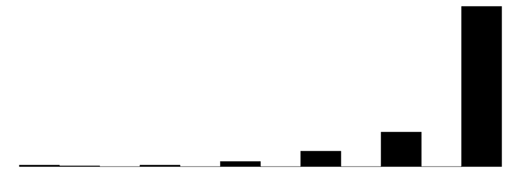

vote_importance

7

0

0.0

1.0

-5.9

0.5

0.5

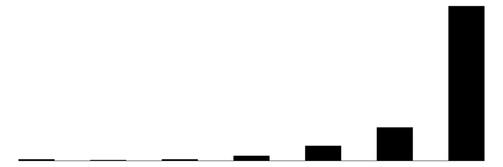

```r
survey_data <- survey_data |>
  mutate(
    vote_importance_raw = vote_importance,  # keep raw variable
    vote_importance = standardize(vote_importance_raw)
  )
survey_data |>
  select(vote_importance_raw, vote_importance) |>
  datasummary_skim()
```

##### Party Identity Strength

Unique

Missing Pct.

Mean

SD

Min

Median

Max

Histogram

party_identity_strength_raw

6

0

3.4

1.2

1.0

4.0

5.0

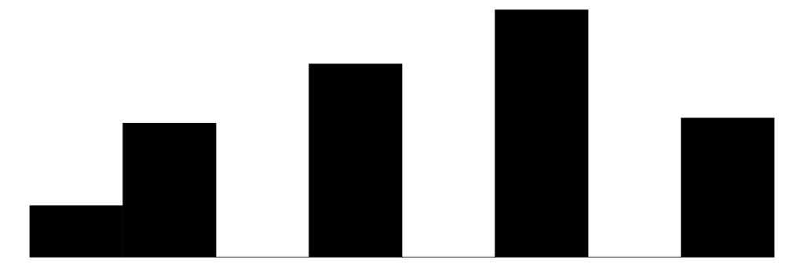

party_identity_strength

6

0

-0.0

1.0

-2.0

0.5

1.4

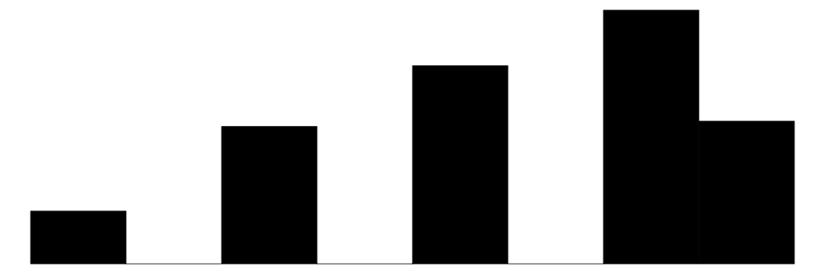

```r
survey_data <- survey_data |>
  mutate(
    party_identity_strength_raw = party_identity_strength,  # keep raw variable
    party_identity_strength = standardize(party_identity_strength_raw)
  )

survey_data |>
  select(party_identity_strength_raw, party_identity_strength) |>
  datasummary_skim()
```

##### Political Engagement

Political Engagement Scale: 3 items (political_interest 1-5, political_discussion 1-4, political_follow 1-4). Reverse code: political_discussion, political_follow. Range: 3-13.

```r
# Reverse code items
survey_data <- survey_data |>
  mutate(
    political_discussion_r = 5 - political_discussion,  # Reverse 1-4 scale
    political_follow_r = 5 - political_follow           # Reverse 1-4 scale
  )

# Calculate sum score
survey_data <- survey_data |>
  mutate(
    political_engagement_raw = political_interest +
                               political_discussion_r +
                               political_follow_r,
    political_engagement = standardize(political_engagement_raw)
  )
```

```r
engagement_omega <- survey_data |>
  select(political_interest, political_discussion_r, political_follow_r) |>
  ci.reliability(data = _,
                 type = "omega",
                 interval.type = "mlr",
                 conf.level = 0.95)

engagement_omega
```

```
$est
[1] 0.7914

$se
[1] 0.02462

$ci.lower
[1] 0.7432

$ci.upper
[1] 0.8397

$conf.level
[1] 0.95

$type
[1] "omega"

$interval.type
[1] "robust maximum likelihood (wald ci)"
```

##### General Health

Unique

Missing Pct.

Mean

SD

Min

Median

Max

Histogram

health_general_raw

5

0

3.9

0.8

1.0

4.0

5.0

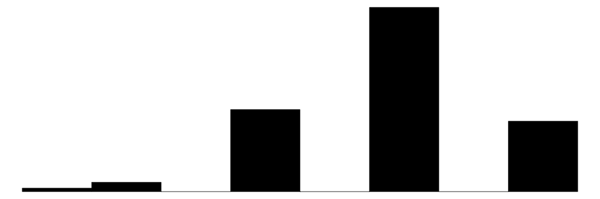

health_general

5

0

-0.0

1.0

-3.7

0.1

1.4

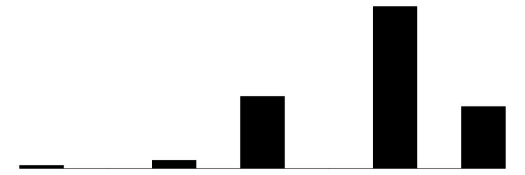

```r
survey_data <- survey_data |>
  mutate(
    health_general_raw = health_general,  # keep raw variable
    health_general = standardize(health_general_raw)
  )

survey_data |>
  select(health_general_raw, health_general) |>
  datasummary_skim()
```

##### Health and Politics

Health-Politics Scale: 10 items (health_politics_01 to health_politics_10, 1-5 Likert). All items negatively worded. Final sum reversed so higher scores indicate better health. Range: 10-50.

```r
# Calculate raw sum score (higher = worse health)
survey_data <- survey_data |>
  mutate(
    health_politics_raw_unreversed = health_politics_01 + health_politics_02 +
                                     health_politics_03 + health_politics_04 +
                                     health_politics_05 + health_politics_06 +
                                     health_politics_07 + health_politics_08 +
                                     health_politics_09 + health_politics_10
  )

# Reverse the sum so higher = better health
# Min=10, Max=50, so reverse: 60 - sum
survey_data <- survey_data |>
  mutate(
    health_politics_raw = 60 - health_politics_raw_unreversed,
    health_politics = standardize(health_politics_raw)
  )
```

```r
health_politics_omega <- survey_data |>
  select(health_politics_01:health_politics_10) |>
  ci.reliability(
    data = _,
    type = "omega",
    interval.type = "mlr",
    conf.level = 0.95)

health_politics_omega
```

```
$est
[1] 0.9028

$se
[1] 0.009408

$ci.lower
[1] 0.8844

$ci.upper
[1] 0.9212

$conf.level
[1] 0.95

$type
[1] "omega"

$interval.type
[1] "robust maximum likelihood (wald ci)"
```

##### PSS-10

Perceived Stress Scale (PSS-10): 10 items (PSS_01 to PSS_10, 0-4 scale). Reverse code: PSS_04, PSS_05, PSS_07, PSS_08 (positively worded items). Higher scores indicate greater stress. Range: 0-40.

```r
# Reverse code positively worded items
survey_data <- survey_data |>
  mutate(
    PSS_04_r = 4 - PSS_04,  # Reverse 0-4 scale
    PSS_05_r = 4 - PSS_05,
    PSS_07_r = 4 - PSS_07,
    PSS_08_r = 4 - PSS_08
  )

# Calculate raw sum score
survey_data <- survey_data |>
  mutate(
    stress_general_raw = PSS_01 + PSS_02 + PSS_03 + PSS_04_r + PSS_05_r +
                         PSS_06 + PSS_07_r + PSS_08_r + PSS_09 + PSS_10,
    stress_general = standardize(stress_general_raw)
  )
```

```r
stress_general_omega <- survey_data |>
  select(PSS_01, PSS_02, PSS_03, PSS_04_r, PSS_05_r,
         PSS_06, PSS_07_r, PSS_08_r, PSS_09, PSS_10) |>
  ci.reliability(
    data = _,
    type = "omega",
    interval.type = "mlr",
    conf.level = 0.95)

stress_general_omega
```

```
$est
[1] 0.8929

$se
[1] 0.01221

$ci.lower
[1] 0.8689

$ci.upper
[1] 0.9168

$conf.level
[1] 0.95

$type
[1] "omega"

$interval.type
[1] "robust maximum likelihood (wald ci)"
```

##### Political Stress

Unique

Missing Pct.

Mean

SD

Min

Median

Max

Histogram

stress_politics_raw

5

0

1.7

1.1

0.0

2.0

4.0

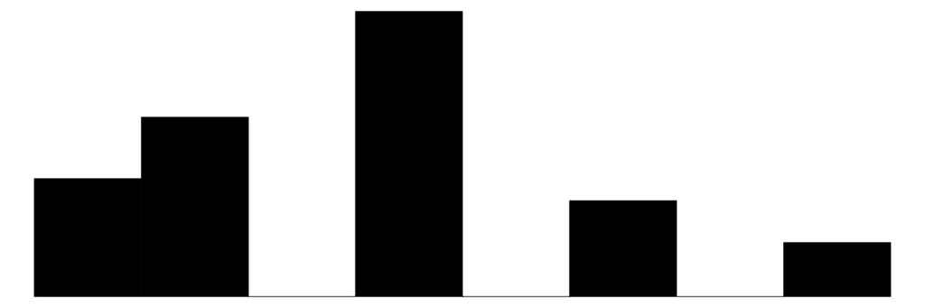

stress_politics

5

0

-0.0

1.0

-1.5

0.3

2.1

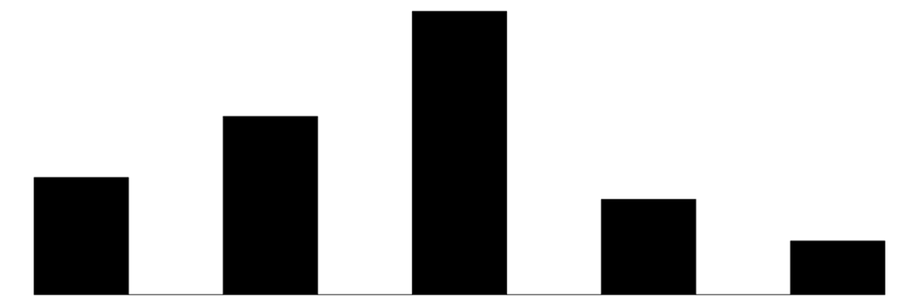

```r
survey_data <- survey_data |>
  mutate(
    stress_politics_raw = stress_politics,  # keep raw variable
    stress_politics = standardize(stress_politics_raw)
  )

survey_data |>
  select(stress_politics_raw, stress_politics) |>
  datasummary_skim()
```

##### Depression

Depression Scale (PHQ-8): 8 items (depression_01 to depression_08, 0-3 scale). All items are depression symptoms. Higher scores indicate greater depression. Range: 0-24.

```r
# Calculate raw sum score
survey_data <- survey_data |>
  mutate(
    depression_raw = depression_01 + depression_02 + depression_03 + depression_04 +
                     depression_05 + depression_06 + depression_07 + depression_08,
    depression = standardize(depression_raw)
  )
```

```r
depression_omega <- survey_data |>
  select(depression_01:depression_08) |>
  ci.reliability(
    data = _,
    type = "omega",
    interval.type = "mlr",
    conf.level = 0.95)

depression_omega
```

```
$est
[1] 0.9048

$se
[1] 0.00974

$ci.lower
[1] 0.8857

$ci.upper
[1] 0.9239

$conf.level
[1] 0.95

$type
[1] "omega"

$interval.type
[1] "robust maximum likelihood (wald ci)"
```

##### Selected survey data

```r
# for descriptives (re-order)
survey_data_fin <- survey_data |>
  select(PROLIFIC_PID, id, PID,
         date, timer_total,
         commitment,
         attention_01, attention_02,
         manip_check_01:party_closer,
         party_identity_strength_raw, party_identity_strength,
         party_preference, party_intensity,
         valence_democrats:arousal_republicans,
         affpol_raw, affpol_weighted,
         bipartisan_support, social_polarization,
         ideology,
         democratic_support_raw, democratic_support,
         vote_election, vote_importance_raw, vote_importance,
         political_engagement_raw, political_engagement,
         health_general_raw, health_general,
         health_politics_raw, health_politics,
         stress_general_raw, stress_general,
         stress_politics_raw, stress_politics,
         depression_raw, depression,
         age:income,
         bipartisanship_01, bipartisanship_02,
         friends_democrats, friends_republicans,
         dem_01:dem_07, dem_01_r:dem_07_r,
         political_interest:political_follow,
         political_discussion_r, political_follow_r,
         health_politics_01:health_politics_10,
         PSS_01:PSS_10, PSS_04_r:PSS_08_r,
         depression_01:depression_08,
         max_boxes:hard95,
         work_total:work_voterural,
         work_ingroup, work_outgroup, work_difference,
         )
```

```r
# for merging
survey_selection <- survey_data_fin |>
  select(PROLIFIC_PID,
         PID:depression_08,
         work_total:work_difference)
```

### Create combined dataframe

```r
combined_data <- task_data |>
  left_join(survey_selection, by = "PID")
```

Create in-group / out-group coding

```r
combined_data <- combined_data |>
  mutate(
    benefit = case_when(
      agent == "VOTEALL" ~ "EVERYONE",
      agent == "VOTEURBAN" & (party == "Democrat" | party_closer == "Democrat") ~ "INGROUP",
      agent == "VOTERURAL" & (party == "Democrat" | party_closer == "Democrat") ~ "OUTGROUP",
      agent == "VOTERURAL" & (party == "Republican" | party_closer == "Republican") ~ "INGROUP",
      agent == "VOTEURBAN" & (party == "Republican" | party_closer == "Republican") ~ "OUTGROUP",
      .default = NA_character_
    )
  )
```

Reorder combined data

```r
combined_data <- combined_data |>
  select(PROLIFIC_PID, id, PID, date:commitment,
         agent, benefit, eff:hard95_nboxes,
         attention_01:work_difference)
```

## Data exclusion criteria

We will exclude data from participants who meet any of the following criteria:

1. Indicate at the start of the study that they will not pay attention (i.e., select “No, I will not” in response to the attention pledge).

```r
exclusion_01 <- survey_data_fin |>
  filter(commitment != "Yes, I will") |>
  select(PROLIFIC_PID, party, age, gender, ethnicity01, education)

# Count and display
cat("N excluded:", nrow(exclusion_01))
```

```
N excluded: 0
```

```r
exclusion_01
```

```
# A tibble: 0 × 6
# ℹ 6 variables: PROLIFIC_PID <chr>, party <fct>, age <dbl>, gender <fct>, ethnicity01 <fct>, education <fct>
```

2. Fail at least one of two attention checks embedded in the post-task survey (e.g., “Please select ‘Strongly disagree’ as your response to this item”).

```r
exclusion_02 <- survey_data_fin |>
  filter(attention_01 == "failed" | attention_02 == "failed") |>
  select(PROLIFIC_PID, party, age, gender, ethnicity01, education,
         attention_01, attention_02)

cat("N excluded:", nrow(exclusion_02))
```

```
N excluded: 10
```

```r
exclusion_02
```

```
# A tibble: 10 × 8
   PROLIFIC_PID party        age gender ethnicity01               education               attention_01 attention_02
   <chr>        <fct>      <dbl> <fct>  <fct>                     <fct>                   <fct>        <fct>
 1 131          Republican    49 Woman  White                     Postgraduate degree     passed       failed
 2 162          Democrat      70 Man    White                     Less than high school   passed       failed
 3 220          Republican    44 Woman  White                     2-year college degree   passed       failed
 4 228          Democrat      56 Woman  Black or African-American High school             failed       passed
 5 264          Democrat      23 Woman  White                     4-year college degree   passed       failed
 6 281          Democrat      62 Woman  Black or African-American College, but not degree passed       failed
 7 54           Republican    51 Man    White                     2-year college degree   passed       failed
 8 57           Democrat      51 Man    White                     4-year college degree   failed       passed
 9 76           Democrat      60 Woman  White                     2-year college degree   failed       passed
10 91           Democrat      67 Woman  White                     Postgraduate degree     passed       failed
```

3. Missed more than half of the trials (>13 of 27) in the pro-democratic effort task (i.e., no response within the time limit)

```r
exclusion_03 <- combined_data |>
  group_by(PROLIFIC_PID) |>
  summarise(
    n_missed = sum(is.na(decision)),
    n_total = n(),
    .groups = "drop"
  ) |>
  filter(n_missed > 13) |>
  left_join(
    survey_data_fin |>
      select(PROLIFIC_PID, party, age, gender, ethnicity01, education),
    by = "PROLIFIC_PID"
  ) |>
  select(PROLIFIC_PID, n_missed, n_total, party, age, gender, ethnicity01, education)

# Count and display
cat("N excluded:", nrow(exclusion_03))
```

```
N excluded: 4
```

```r
exclusion_03
```

```
# A tibble: 4 × 8
  PROLIFIC_PID n_missed n_total party        age gender ethnicity01               education
  <chr>           <int>   <int> <fct>      <dbl> <fct>  <fct>                     <fct>
1 193                17      27 Republican    64 Man    White                     2-year college degree
2 220                14      27 Republican    44 Woman  White                     2-year college degree
3 292                20      27 Democrat      70 Man    White                     College, but not degree
4 299                18      27 Democrat      44 Man    Black or African-American 2-year college degree
```

4. Identify as Independent in our survey measures. We recruit only Democrats and Republicans via Prolific’s pre-screening filters. However, occasionally some Independents may still be included in the sample due to discrepancies in Prolific’s demographic data. As our main analyses focus on Democrats and Republicans, we will exclude these participants.

```r
exclusion_04 <- survey_data_fin |>
  filter(party %in% c("Independent", "Other")) |>
  select(PROLIFIC_PID, party, age, gender, ethnicity01, education)

cat("N excluded:", nrow(exclusion_04))
```

```
N excluded: 1
```

```r
exclusion_04
```

```
# A tibble: 1 × 6
  PROLIFIC_PID party         age gender ethnicity01 education
  <chr>        <fct>       <dbl> <fct>  <fct>       <fct>
1 156          Independent    61 Man    White       College, but not degree
```

5. Do not reach the end of the study (i.e., complete the effort task but do not complete the survey measures)

(already excluded by default)

### Overview

```r
# Sequential exclusion counting (non-overlapping)
excluded_pids <- character(0)

# List of exclusions with labels
exclusions_list <- list(
  "No attention pledge" = exclusion_01,
  "Failed attention check" = exclusion_02,
  "Missed >13 trials" = exclusion_03,
  "Independent/Other party" = exclusion_04
)

# Count additional exclusions at each step
exclusion_summary <- map_dfr(names(exclusions_list), function(reason) {
  df <- exclusions_list[[reason]]

  # For duplicates, count unique PIDs only
  if (reason == "Duplicate entries") {
    unique_pids <- unique(df$PROLIFIC_PID)
    new_exclusions <- setdiff(unique_pids, excluded_pids)
  } else {
    new_exclusions <- setdiff(df$PROLIFIC_PID, excluded_pids)
  }

  # Update cumulative excluded list
  excluded_pids <<- c(excluded_pids, new_exclusions)

  tibble(
    exclusion_reason = reason,
    n_additional = length(new_exclusions)
  )
})

# Add starting N and final N
exclusion_summary <- exclusion_summary |>
  add_row(exclusion_reason = "Starting N", n_additional = nrow(survey_data_fin), .before = 1) |>
  mutate(n_remaining = nrow(survey_data_fin) - cumsum(replace(n_additional, 1, 0)))

# Display
cat("\nSequential Exclusion Summary\n")
```

```
Sequential Exclusion Summary
```

```r
exclusion_summary |> tt()
```

| exclusion_reason | n_additional | n_remaining |
| --- | --- | --- |
| Starting N | 298 | 298 |
| No attention pledge | 0 | 298 |
| Failed attention check | 10 | 288 |
| Missed >13 trials | 3 | 285 |
| Independent/Other party | 1 | 284 |

```r
cat("\nFinal N after all exclusions:", tail(exclusion_summary$n_remaining, 1), "\n")
```

```
Final N after all exclusions: 284
```

### Exclude participants

```r
# Collect all Prolific IDs to exclude (exclusions 01-04)
pids_to_exclude <- bind_rows(
  exclusion_01 |> select(PROLIFIC_PID),
  exclusion_02 |> select(PROLIFIC_PID),
  exclusion_03 |> select(PROLIFIC_PID),
  exclusion_04 |> select(PROLIFIC_PID)
) |>
  distinct(PROLIFIC_PID) |>
  pull(PROLIFIC_PID)

# Apply exclusions to survey data
survey_data_exc <- survey_data_fin |>
  filter(!PROLIFIC_PID %in% pids_to_exclude)

# Apply exclusions to combined data
combined_data_exc <- combined_data |>
  filter(!PROLIFIC_PID %in% pids_to_exclude)
```

## Save cleaned data for modelling

```r
# survey data, all cases (for bonus payment)
write_csv(survey_data_fin, here(data_clean_dir, "demeffort_bonus_data.csv"))
save(survey_data_fin, file = here(data_clean_dir, "demeffort_bonus_data.RData"))

# survey data, analysis data
write_csv(survey_data_exc, here(data_clean_dir, "demeffort_survey_data.csv"))
save(survey_data_exc, file = here(data_clean_dir, "demeffort_survey_data.RData"))

# combined data (for computational and regression models)
write_csv(combined_data_exc, here(data_clean_dir, "demeffort_combined_data.csv"))
save(combined_data_exc, file = here(data_clean_dir, "demeffort_combined_data.RData"))
```